# Can You Rule Riddler Nation - FiveThirtyEight Riddle

### Initialization and Comparison

First we have a function named init_pop(n) which will allows us to randomely generate n viable strategies. Additionally we initialize each strategies score to 0.

The fight(s1, s2) method serves as a function to compare to strategies. Fight(s1, 2s) returns a list with a 1 for the winning strategy, and a 0 for the losing strategy. The logic in this function is as specified by FiveThirtyEight's riddle.

DESIGN DECISION:  
The question of generating random strategies is not trivial. How can we quickly fill a list with 100 (or near 100) total soldiers? Of course we can pick random numbers, but in order to complete this task in just one pass through of the ten castles, we must keep track of how many soldiers we have deployed as we go. Thus, picking a random number ranging from 0 to the remaining number of available soldiers may skew the stratgey to having more soldiers towards the beginning. Thus, I have implemented two design decisions to help comabt this. First, the random number of soldiers is chosen from 0 to the remaining available / 2. This prevents the random number from being too high, and depriving many castles of soldiers later on. Second, The first castle considered is the most valuable castle. This decision will hopefully reflect the idea that many participants in the competition will likely send a disproportionately high number of soldiers to the more valuvable castles.

```python
import random

def init_pop(n):

    strats = []
    for i in range(n):
        sols = 100
        castles = []
        for t in range(10):
            delegation = random.randint(0, sols / 2)
            castles.insert(0, delegation)
            sols -= delegation
        strats.append([castles, 0])
    return strats

def fight(s1, s2):
    s1 = s1[0]
    s2 = s2[0]
    s1score = 0
    s2score = 0
    for i in range(10):
        if s1[i] > s2[i]:
            s1score += i + 1
        if s1[i] < s2[i]:
            s2score += i + 1

#     return [s1score, s2score]

    if s1score > s2score:
        return [1 , 0]
    elif s1score < s2score:
        return [0, 1]
    else:
        return [0.5, 0.5]

#     score differential
#     return [s1score - s2score, s2score-s1score]
```

### Strategy Fitness (Rankings)

Next, we define a function compute_scores(population) that will allow us to simulate a round robin style tournament between all our current candidate strategies. This method returns a sorted list of the stretegies with the highest performing ones at the beginning, where the first element of the list is the strategy, and the second is the number of wins this strategy acuired in the round robin simulation.

```python
def compute_scores(population):

    #re init scores
    for i in range(len(population)):
        population[i][1] = 0

    for i in range(len(population)):
        for i2 in range(i+1, len(population)):

            res = fight(population[i], population[i2])
            population[i][1] += res[0]
            population[i2][1] += res[1]

    population = sorted(population, key=lambda x: x[1], reverse=True)

    return population
```

### Genetic Algorithm

```python
def evolve(strats):

    elites = strats[0:len(strats) / 5]
    print '--------------------------------'
    print '---------top teams are:---------'

    df = pd.DataFrame(elites[:3], columns=['strategy', 'score'])
    print df

    print
    print
    pack = strats[:len(strats) / -5]

    # mutations
    pack.extend(init_pop(len(strats) / 100))


    new_strats = mating(pack)
    new_strats.extend(elites)
    new_strats_scored = compute_scores(new_strats)

    new_strats_scored = sorted(new_strats_scored, key=lambda x: x[1], reverse=True)

    return new_strats_scored


def mate(t1, t2):

    new = []
    r = 0
    for i in range(10):
        r += 1
        if r % 2 == 0:
            new.append(t1[0][i])
        else:
            new.append(t2[0][i])
    return new


def check_constraints(strat):
    s = 0
    for i in strat:
        s += i
    if s > 100 or s < 80:
        return False
    return True


def mating(pack):
    new_teams = []
    i = 0

    packlen = len(pack)
    while i <= (packlen - 1):
        possible = mate(pack[i], pack[random.randint(i / 2, i)])
        if check_constraints(possible):
            possible_w_score = [possible, 0]
            new_teams.append(possible_w_score)

            i += 1

    return new_teams
```

### Running the genetic algorithm for n generations with an inital population pop:

```python
def run(pop, n):
    w_percs = []
    top_team_per_gen = []
    for i in range(n):
        print 'generation: ' + str(i) + '; population: ' + str(len(pop))
        pop = evolve(pop)
        top_team_per_gen.append(pop[0][0])
        wp = pop[0][1] / float(len(pop)) * 100
        w_percs.append(wp)
        print 'top winning %: ' + str(wp)
    return [top_team_per_gen, w_percs]
```

### Finally, some sample results:

DESIGN DECISION:  
The parameters of an initial population of 10000 with 25 generations were chosen because I believe that it is particularly important to include a wide variety of viable strategies to test against. 25 generations were chosen in an interest of time since the population was chosen to be so large. I believe this type of setup is more effective than one with say a population of 1000 and 100 generations because we would like to eliminate the chance that one strategy may perform particularly well against 1000 others, but not against different types (overfitting.) Having 10000 strategies in the population forces successful strategies to be effective against a very wide variety of other strategies.

```python
strats = init_pop(10000)
generations = 25
res = run(strats, generations)
data = res[0]
w_percs = res[1]
```

```
generation: 0; population: 10000
--------------------------------
---------top teams are:---------
                              strategy  score
0  [4, 6, 12, 1, 22, 20, 3, 13, 3, 12]      0
1     [3, 6, 1, 0, 0, 7, 27, 6, 8, 30]      0
2    [4, 0, 8, 7, 1, 0, 14, 19, 3, 40]      0


top winning %: 83.6930693069
generation: 1; population: 10100
--------------------------------
---------top teams are:---------
                              strategy  score
0   [2, 2, 6, 4, 9, 16, 18, 15, 19, 8]   8453
1  [0, 1, 4, 6, 4, 10, 12, 20, 25, 18]   8358
2   [2, 4, 4, 8, 10, 7, 15, 27, 16, 4]   8338


top winning %: 85.4082933046
generation: 2; population: 10201
--------------------------------
---------top teams are:---------
                              strategy   score
0   [0, 4, 5, 6, 10, 16, 18, 25, 8, 8]  8712.5
1  [1, 4, 5, 6, 10, 17, 18, 24, 1, 13]  8538.0
2  [0, 3, 5, 5, 10, 14, 18, 20, 8, 17]  8512.0


top winning %: 84.5224228305
generation: 3; population: 10302
--------------------------------
---------top teams are:---------
                             strategy   score
0  [0, 4, 5, 6, 10, 16, 18, 25, 8, 8]  8707.5
1  [0, 4, 5, 6, 10, 16, 18, 25, 8, 8]  8707.5
2  [0, 3, 5, 9, 10, 16, 18, 22, 8, 9]  8646.0


top winning %: 85.452710496
```

[output cut: 195 more lines]

```
1  [2, 2, 0, 11, 8, 0, 20, 31, 25, 1]  12278.5
2  [2, 2, 0, 11, 8, 0, 20, 31, 25, 1]  12278.5


top winning %: 96.940386893
generation: 24; population: 12665
--------------------------------
---------top teams are:---------
                             strategy    score
0  [2, 2, 0, 11, 8, 0, 20, 31, 25, 1]  12277.5
1  [2, 2, 0, 11, 8, 0, 20, 31, 25, 1]  12277.5
2  [2, 2, 0, 11, 8, 0, 20, 31, 25, 1]  12277.5


top winning %: 97.7523258541
```

### Analysis

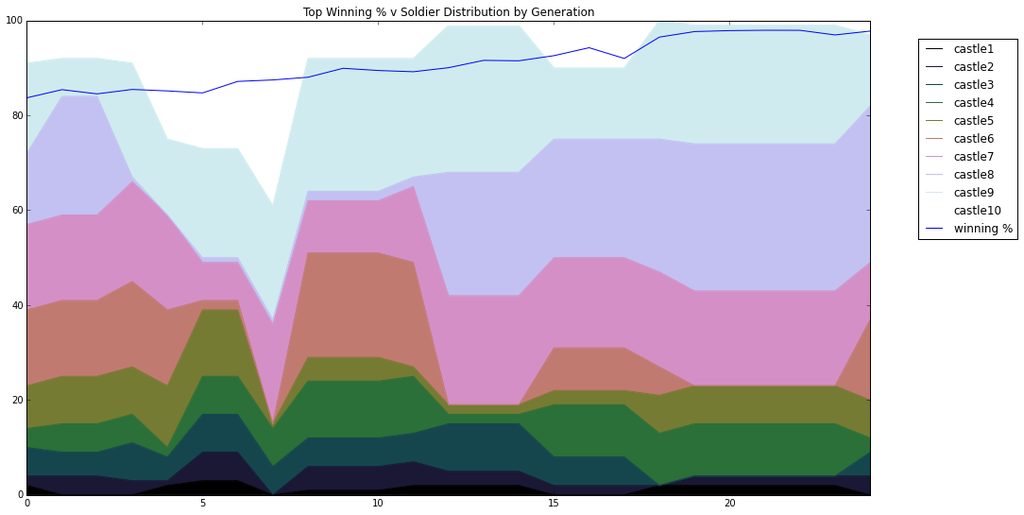

```python
%matplotlib inline
import numpy as np
import pandas as pd
import matplotlib.pyplot as plt

step = np.tile([x + 1 for x in range(generations)], 10)
walk = np.repeat([x + 1 for x in range(10)], generations)
df = pd.DataFrame(np.c_[np.asarray(data)],
                  columns=["castle1", "castle2", "castle3", "castle4", "castle5",
                           "castle6", "castle7", "castle8", "castle9", "castle10"])

ax = df.plot(kind='area', stacked = True, ylim = (0, 100), colormap='cubehelix', title='Soldier Distribution', figsize=(16,9))
w_perc = pd.DataFrame(w_percs, columns=['winning %'])
w_perc.plot(title='Top Winning % v Soldier Distribution by Generation', ax=ax)
plt.legend(loc='center left', bbox_to_anchor=(1.05, 0.75))
```

### Analysis

Above we see a stacked graph showing the change in distribution of soldiers over generations. It is interesting to notice how the genetic algorithm evolves over time to adapt to its previous generations, due to the persistence of the 'elite.' Below, the upper graph shows a rolling average of the size of troops of the previous 5 generations for each castle. The lower graph plots a rolling average of winning percentage. With these graphs we can easily tell that the top winning percentage was consistently rising, and we can see the way changes in strategy lined up with changes in win percentage.

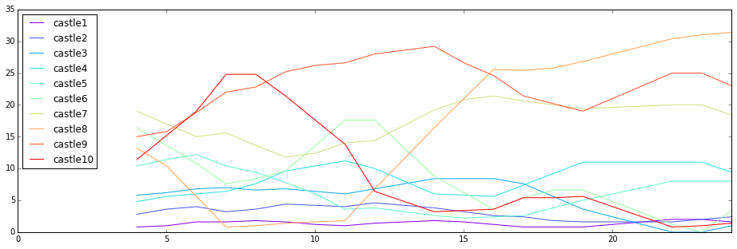

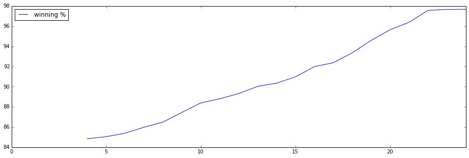

```python
rm = pd.rolling_mean(df, 5).plot(figsize=(16,5), colormap='rainbow')
rmw = pd.rolling_mean(w_perc, 5).plot(figsize=(16,5))
rm
```

# Overall

The top strategy we ended up finding, in terms of win percentage against its respective generation, was [2, 2, 0, 11, 8, 0, 20, 31, 25, 1].